# Projekt 1

Adrian Gąsiorowski, Agnieszka Linowska, Bartosz Piotrowski, Krzysztof Rutkowski

12.04.2016r.

# 1. Wstęp

W poniższej prezentacji pokażemy analizę wybranych stacji pod kątem scenariusza B, tj. analizę wybranych grup odwiedzających pod kątem czasu przebywania przy eksponatach.

## 1.1. Wstępne przetworzenie danych

```r
library(ggplot2)
library(cluster)
library(reshape)
library(MASS)
```

Przetwarzamy wstępnie dane, odrzucając poniedziałki, godziny wcześniejsze niż 10 oraz późniejsze niż 18 oraz kolumnę ze scenami; wczytujemy wyczyszczone dane.

```r
load("smallLogs.rda")
data <- smallLogs[!smallLogs$visitor == "-1",]
data <- data[-nrow(data),-5]
data <- cbind(data, d_of_w = weekdays(as.POSIXlt(data$date)), month = (as.POSIXlt(data$date)$mon + 1))
data <- data[!data$d_of_w=="poniedziałek",]
data <- data[as.POSIXlt(data$date)$hour >= 10 & as.POSIXlt(data$date)$hour < 18,]
```

```r
head(data)
```

```
##                   date station visitor     type d_of_w month
## 17 2012-01-03 10:03:27  cnk02a  795680  Leaving wtorek     1
## 18 2012-01-03 10:03:27  cnk02a  795680 Entering wtorek     1
## 19 2012-01-03 10:03:44  cnk02a  795680  Leaving wtorek     1
## 20 2012-01-03 10:03:44  cnk02a  795680 Entering wtorek     1
## 21 2012-01-03 10:03:47  cnk02a  795681  Leaving wtorek     1
## 22 2012-01-03 10:03:47  cnk02a  795681 Entering wtorek     1
```

## 1.2 Dalsze przetworzenie danych - agregacja czasu, skalowanie

```r
time_spent <- function(dates) {
  date_2 <- max(as.POSIXlt(dates))
  date_1 <- min(as.POSIXlt(dates))
  return(as.numeric(difftime(date_2, date_1, units = "secs"), units = "secs"))
}

start <- function(date){
  x <- min(as.POSIXlt(date))
  x$hour + x$min/60
}

station_times <- aggregate(date~visitor+station+d_of_w+month, data=data,
                           FUN = function(x) c(time_spent = time_spent(x), start_time = start(x)) )

station_times <- cbind(station_times[,1:4], station_times[,5])
station_times_normal <- station_times[station_times$time_spent < 1500 & station_times$time_spent > 0, ]
```

```r
head(station_times_normal)
```

```
##   visitor station d_of_w month time_spent start_time
## 1  801439  cnk02a Friday     1         20   12.48333
## 2  801447  cnk02a Friday     1         32   10.81667
## 3  801448  cnk02a Friday     1         47   10.80000
## 4  801458  cnk02a Friday     1        478   10.36667
## 5  801482  cnk02a Friday     1         58   11.28333
## 6  801483  cnk02a Friday     1        685   11.30000
```

Następnie tworzymy tabelę przestawną tak, aby każdy odwiedzający był obiektem w 60-wymiarowej przestrzeni euklidesowej zawierającym czasy przebywania przy poszczególnych eksponatach.

```r
station_times_reshaped <- cast(station_times_normal[,c(1,2,5)], visitor ~ station, max)
```

```r
station_times_reshaped[1:10,1:10]
```

```
##    visitor cnk02a cnk02b cnk03 cnk05 cnk06 cnk07 cnk09 cnk100 cnk10
## 1  1000001   -Inf   -Inf  -Inf  -Inf  -Inf  -Inf  -Inf   -Inf  -Inf
## 2  1000002   -Inf     30  -Inf  -Inf  -Inf  -Inf  -Inf   -Inf  -Inf
## 3  1000003   -Inf   -Inf  -Inf  -Inf    83  -Inf  -Inf   -Inf  -Inf
## 4  1000005   -Inf   -Inf  -Inf  -Inf  -Inf  -Inf  -Inf   -Inf  -Inf
## 5  1000006      9   -Inf    68  -Inf  -Inf    81  -Inf   -Inf  -Inf
## 6  1000008   -Inf   -Inf  -Inf  -Inf  -Inf  -Inf  -Inf   -Inf  -Inf
## 7  1000009   -Inf   -Inf  -Inf  -Inf  -Inf  -Inf  -Inf   -Inf  -Inf
## 8  1000010   -Inf   -Inf  -Inf  -Inf  -Inf  -Inf  -Inf   -Inf  -Inf
## 9  1000011      2   -Inf  -Inf  -Inf  -Inf  -Inf     5   -Inf  -Inf
## 10 1000012   -Inf   -Inf  -Inf  -Inf  -Inf  -Inf  -Inf   -Inf  -Inf
```

Gdy użytkownika nie było przy danej stacji wstawiamy zero. Następnie przeskalowujemy całą tabelę.

```r
station_times_reshaped[station_times_reshaped < 0] <- 0
station_times_reshaped_scaled <- scale(station_times_reshaped)
station_times_reshaped_scaled[1:10,1:6]
```

```
##              cnk02a     cnk02b      cnk03      cnk05      cnk06      cnk07
## 1000001 -0.23320168 -0.2224128 -0.2410348 -0.2831548 -0.2169065 -0.3105481
## 1000002 -0.23320168  0.3285538 -0.2410348 -0.2831548 -0.2169065 -0.3105481
## 1000003 -0.23320168 -0.2224128 -0.2410348 -0.2831548  1.6800528 -0.3105481
## 1000005 -0.23320168 -0.2224128 -0.2410348 -0.2831548 -0.2169065 -0.3105481
## 1000006 -0.06383929 -0.2224128  0.7915557 -0.2831548 -0.2169065  1.3376449
## 1000008 -0.23320168 -0.2224128 -0.2410348 -0.2831548 -0.2169065 -0.3105481
## 1000009 -0.23320168 -0.2224128 -0.2410348 -0.2831548 -0.2169065 -0.3105481
## 1000010 -0.23320168 -0.2224128 -0.2410348 -0.2831548 -0.2169065 -0.3105481
## 1000011 -0.19556559 -0.2224128 -0.2410348 -0.2831548 -0.2169065 -0.3105481
## 1000012 -0.23320168 -0.2224128 -0.2410348 -0.2831548 -0.2169065 -0.3105481
```

Tworzymy także tabelę z wartościami logicznymi informującymi o tym, czy dany użytkownik odwiedził dany eksponat.

```r
station_bool_reshaped <- as.data.frame(station_times_reshaped[,-1] > 0)
rownames(station_bool_reshaped) <- station_times_reshaped[,1]
station_bool_reshaped[1:10,1:10]
```

```
##         cnk02a cnk02b cnk03 cnk05 cnk06 cnk07 cnk09 cnk100 cnk10 cnk11
## 1000001  FALSE  FALSE FALSE FALSE FALSE FALSE FALSE  FALSE FALSE FALSE
## 1000002  FALSE   TRUE FALSE FALSE FALSE FALSE FALSE  FALSE FALSE FALSE
## 1000003  FALSE  FALSE FALSE FALSE  TRUE FALSE FALSE  FALSE FALSE FALSE
## 1000005  FALSE  FALSE FALSE FALSE FALSE FALSE FALSE  FALSE FALSE FALSE
## 1000006   TRUE  FALSE  TRUE FALSE FALSE  TRUE FALSE  FALSE FALSE FALSE
## 1000008  FALSE  FALSE FALSE FALSE FALSE FALSE FALSE  FALSE FALSE FALSE
## 1000009  FALSE  FALSE FALSE FALSE FALSE FALSE FALSE  FALSE FALSE FALSE
## 1000010  FALSE  FALSE FALSE FALSE FALSE FALSE FALSE  FALSE FALSE FALSE
## 1000011   TRUE  FALSE FALSE FALSE FALSE FALSE  TRUE  FALSE FALSE  TRUE
## 1000012  FALSE  FALSE FALSE FALSE FALSE FALSE FALSE  FALSE FALSE FALSE
```

# 2. Analiza klastrów

Ponieważ otrzymana tabela jest duża, chcemy ją zmniejszyć, by lepiej poddawała się analizie. Ograniczymy ją do najczęściej odwiedzanych stacji i usuniemy mało aktywnych zwiedzających.

Znajdujemy najczęściej odwiedzane eksponaty:

```r
visit_count <- apply(station_bool_reshaped, 2, sum)
visit_count_order <- order(visit_count, decreasing = T)
most_frequent_stations <- visit_count[visit_count_order]
most_frequent_stations[1:10]
```

```
## cnk19a  cnk16 cnk19b cnk02a  cnk18  cnk12 cnk02b  cnk10  cnk09 cnk78a
##  55960  36697  32818  31598  31250  30802  28868  28013  27866  26818
```

```r
exhibits_count <- apply(station_bool_reshaped, 1, sum)
quantile(exhibits_count)
```

```
##   0%  25%  50%  75% 100%
##    1    3    6   11   49
```

```r
mean(exhibits_count)
```

```
## [1] 7.583437
```

```r
active_visitors <- names(exhibits_count[exhibits_count>5 & exhibits_count<40])
length(active_visitors)
```

```
## [1] 81204
```

## 2.1 Redukcja wymiarów

Stosujemy metodę isoMDS do uprzednio wyliczonej macierzy odległości. Patrzymy przy pomocy funkcji Shepard, czy zredukowane dane dobrze zachowują odległości pomiędzy obiektami.

```r
s <- sample(active_visitors, 3000)
small_station_times_reshaped_scaled <- station_times_reshaped_scaled[s,names(most_frequent_stations)[1:10]]
small_dist <- daisy(small_station_times_reshaped_scaled)
small_dist[small_dist==0] <- 0.0001
d2_small_dist <- isoMDS(small_dist, k=2)
```

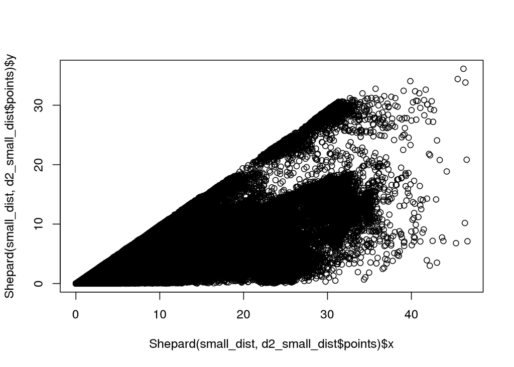

```r
plot(Shepard(small_dist, d2_small_dist$points))
```

## 2.2 Analiza wykresów

Z wykresu dla danych ze zredukowanej przestrzeni możemy określić liczbę możliwych klastrów.

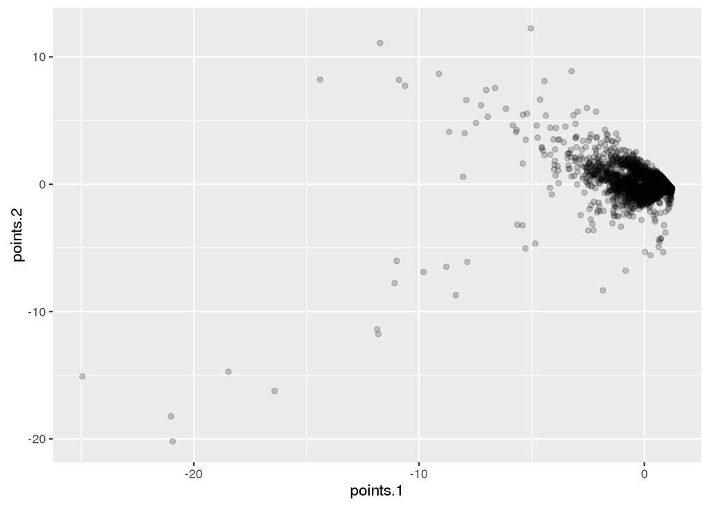

```r
d2_small_dist_df <- data.frame(d2_small_dist)
ggplot(d2_small_dist_df, aes(x=points.1, y=points.2)) + geom_point(size = 1.5, alpha=.2)
```

## 2.3 Obliczenie klastrów

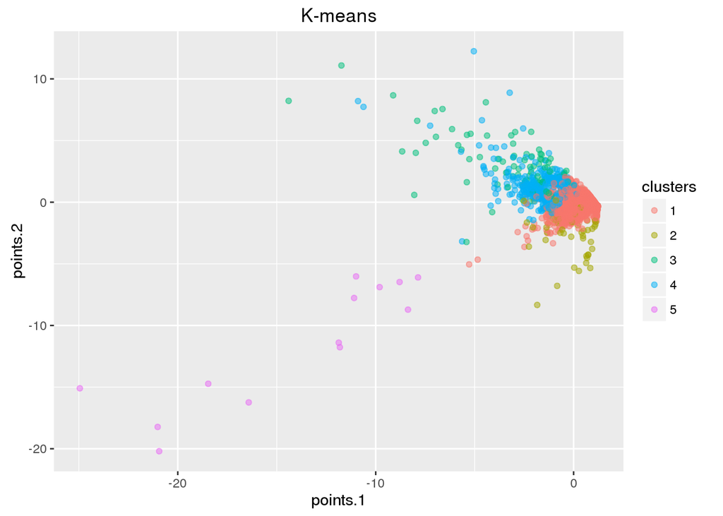

```r
clusters <- kmeans(small_station_times_reshaped_scaled, 5)
d2_small_dist_df$clusters <- factor(clusters$cluster)
ggplot(d2_small_dist_df, aes(x=points.1, y=points.2, colour=clusters)) + geom_point(size = 1.5, alpha=.5) + ggtitle("K-means")
```

## 2.4 Inna analiza klastrów

Podobną analizę przeprowadzamy dla tebeli z wartościami logicznymi zamiast czasów.

```r
s <- sample(active_visitors, 3000)
small_station_bool <- station_bool_reshaped[s,]
small_dist_bool <- dist(small_station_bool)
small_dist_bool[small_dist_bool==0] <- 0.0001
d2_small_dist_bool <- isoMDS(small_dist_bool, k=2)
```

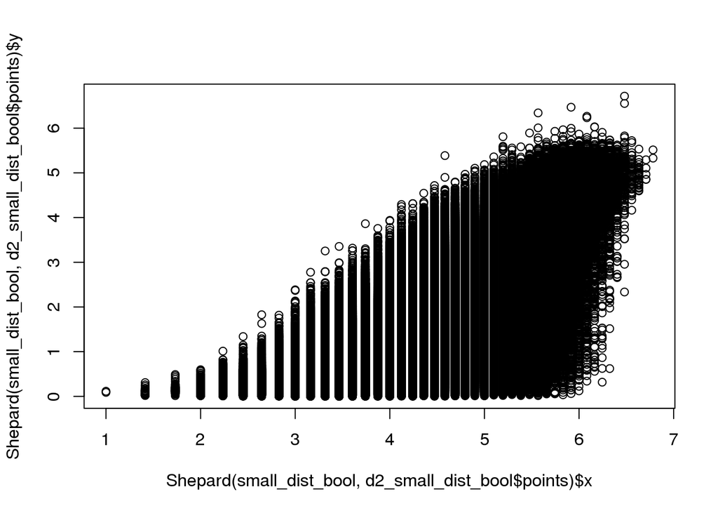

```r
plot(Shepard(small_dist_bool, d2_small_dist_bool$points))
```

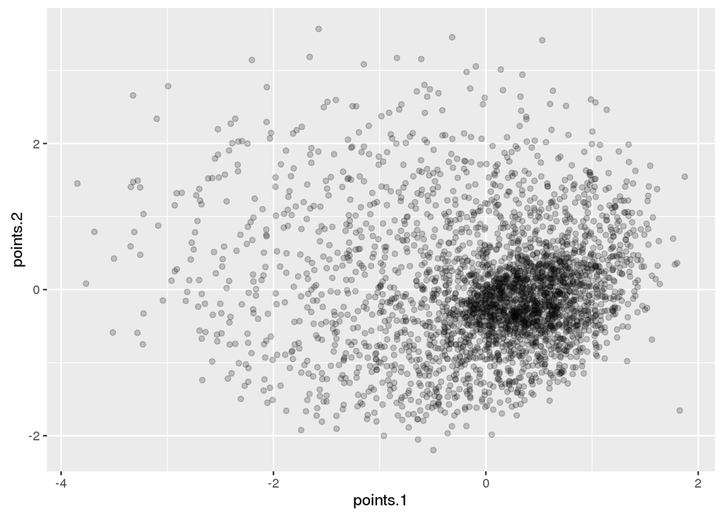

```r
d2_small_dist_bool_df <- data.frame(d2_small_dist_bool)
ggplot(d2_small_dist_bool_df, aes(x=points.1, y=points.2)) + geom_point(size = 1.5, alpha=.2)
```

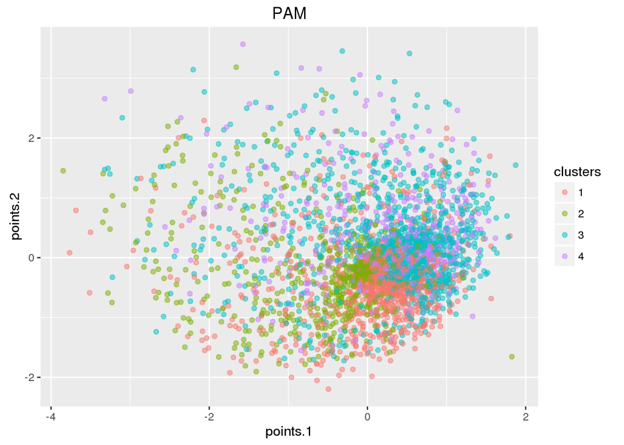

```r
clusters <- pam(small_station_bool, 4)
d2_small_dist_bool_df$clusters <- factor(clusters$cluster)
ggplot(d2_small_dist_bool_df, aes(x=points.1, y=points.2, colour=clusters)) + geom_point(size = 1.5, alpha=.5) + ggtitle("PAM")
```